# Effect of centers on COPDgene traits

Andrey Ziyatdinov

2017-03-15

# 1 About

Some preliminary analysis before conducting genome-wide ancestry scans is necessary.

## 1.1 Protocol

For all models include covariates:

- age, gender
- ever smoker, packs per year
- global ancestry

Define new variables following Michael’s suggestions:

- collapse small groups in `scanner`
- convert `finalGold` into binary

R packages

- `lme4` package and its two functions, `lmer` and `glmer` are used to fit mixed models.
- `lmertest` package performs the inference on model parameters.

## 1.2 Summary of results

- The random effect `(1|ccenter)` is significant in models for all outcomes.
  - Interpretation of top values of the vector of this random effect is reasonable and correlates well with the feature of the centers, i.e. the prevalence of cases.
- The residuals of `FEV1_FVC_utah` model are not OK.
  - Consequently, the global ancestry is not associated with the outcome.
- What meaning does `ever smoker` have? See the plot in section `Two smoking variables SmokCigNow and ATS_PackYears`.

# 2 Data

## 2.1 Phenotypes

```r
phen <- copdgene_phen(traits = "main", acs = "acs_global", progress = FALSE)
phen <- subset(phen, !is.na(acs_global))
```

## 2.2 New Variables

```r
  # define `Age_Enroll2`
  if("Age_Enroll" %in% names(phen)) {
    phen <- mutate(phen,
      Age_Enroll2 = ifelse(is.na(Age_Enroll), NA,
        (Age_Enroll - mean(Age_Enroll, na.rm = TRUE))^2))
  }

  # define `scanner_gr`
  if("scanner" %in% names(phen)) {
    phen <- mutate(phen,
      scanner_gr = ifelse(is.na(scanner), NA,
        ifelse(scanner %in% c("0", "Siemens/Biograph 40", "Philips/40 slice"), "gr",
          scanner)))
  }

  # define `finalGold_bin`
  if("finalGold" %in% names(phen)) {
    phen <- mutate(phen,
      finalGold_bin = ifelse(is.na(finalGold), NA,
        ifelse(finalGold == 0, 0,
        ifelse(finalGold %in% c(2, 3, 4), 1,
        NA))))
  }
```

# 3 Descriptive analysis

## 3.1 Covariates

| Phenotype | Covariates | Notes |
| --- | --- | --- |
| `finalGold` | age, (gender), packs, (SmokCigNow), globalAcs |  |
| `FEV1pp` | age, gender, packs, SmokCigNow, globalAcs |  |
| `FVCpp` | age, gender, packs, SmokCigNow, globalAcs |  |
| `FEV1` | age, age2, gender, height, packs, SmokCigNow, globalAcs | PCs |
| `FVC` | age, age2, gender, height, packs, SmokCigNow, globalAcs | PCs |
| `FEV1_FVC` | age, age2, sex, packs, SmokCigNow, globalAcs | PCs |
| pctEmph | age, gender, packs, SmokCigNow, globalAcs | scanner, (BMI) |
| TLC | age, gender, packs, SmokCigNow, globalAcs | center |

Notes

- For a subset of 3,300 African-Amerticans:
  - `EverSmokedCig` is always `1`
- `pp` phenotypes were derived (see [NHANES III Reference Values](https://www.cdc.gov/niosh/topics/spirometry/nhanes.html)) with adjustment by
  - Gender: Men, Women
  - Ethnicity: African-American, Caucasian, Mexican-American
  - Age Group (years): 16 - 19, 20 - 40, 41 - 60, 61 - 80

## 3.2 Counts on categorical covariates/outcome

| Categorical Varibale | # 0s | # 1s | # NAs |
| --- | --- | --- | --- |
| `EverSmokedCig` | 0 | 3300 | 0 |
| `SmokCigNow` | 657 | 2643 | 0 |
| `gender` | 1846 | 1454 | 0 |
| `finalGold_bin` | 1747 | 824 | 729 |

| outcome | num_na | num_data | num_total | prop_data |
| --- | --- | --- | --- | --- |
| FEV1pp_utah | 40 | 3260 | 3300 | 0.99 |
| FVCpp_utah | 40 | 3260 | 3300 | 0.99 |
| FEV1_utah | 40 | 3260 | 3300 | 0.99 |
| FVC_utah | 40 | 3260 | 3300 | 0.99 |
| FEV1_FVC_utah | 40 | 3260 | 3300 | 0.99 |
| log_pctEmph_Slicer | 585 | 2715 | 3300 | 0.82 |
| TLCpp_race_adjusted | 268 | 3032 | 3300 | 0.92 |

## 3.3 Counts on `ccenter`

```
.
AVA MVA UMN FAL HPR UIA DUK HVA UMC BWH PIT BAY TXS UAB NJC JHU COL USD
  3   3   5   6  16  18  25  33  38  55 110 130 135 136 180 240 304 304
HAR MSM TEM
349 444 766
```

## 3.4 Two smoking variables `SmokCigNow` and `ATS_PackYears`

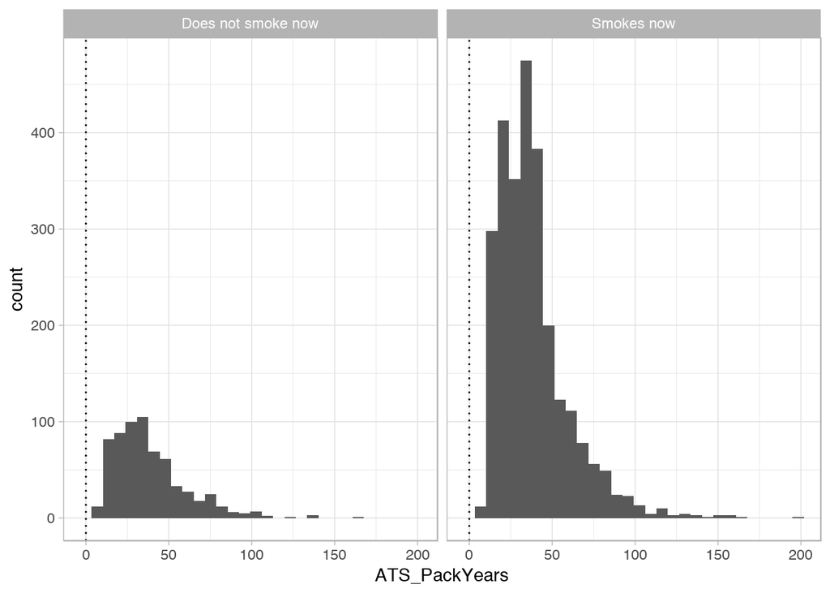

# 4 Linear mixed models

## 4.1 `pp` phenotypes: `FEV1pp_utah` and `FVCpp_utah`

### 4.1.1 `FEV1pp_utah`

```
Linear mixed model fit by REML t-tests use Satterthwaite approximations
  to degrees of freedom [lmerMod]
Formula: FEV1pp_utah ~ Age_Enroll + gender + SmokCigNow + ATS_PackYears +
    acs_global + (1 | ccenter)
   Data: phen

REML criterion at convergence: 29304.8

Scaled residuals:
    Min      1Q  Median      3Q     Max
-3.7550 -0.6133  0.0653  0.6612  3.3637

Random effects:
 Groups   Name        Variance Std.Dev.
 ccenter  (Intercept)  29.12    5.396
 Residual             464.83   21.560
Number of obs: 3260, groups:  ccenter, 21

Fixed effects:
                Estimate Std. Error         df t value Pr(>|t|)
(Intercept)    126.57373    4.93961 1444.00000  25.624  < 2e-16 ***
Age_Enroll      -0.67983    0.05953 3253.00000 -11.419  < 2e-16 ***
gender2         -0.14817    0.77230 3253.00000  -0.192   0.8479
SmokCigNow1     12.70212    1.04081 3254.00000  12.204  < 2e-16 ***
ATS_PackYears   -0.04536    0.01823 3250.00000  -2.488   0.0129 *
acs_global     -18.75957    3.73488 3254.00000  -5.023 5.37e-07 ***
---
Signif. codes:  0 '***' 0.001 '**' 0.01 '*' 0.05 '.' 0.1 ' ' 1

Correlation of Fixed Effects:
            (Intr) Ag_Enr gendr2 SmkCN1 ATS_PY
Age_Enroll  -0.723
gender2     -0.079 -0.020
SmokCigNow1 -0.373  0.369  0.063
ATS_PackYrs  0.045 -0.240  0.050 -0.079
acs_global  -0.626  0.047  0.012 -0.041 -0.024
```

### 4.1.2 `FVCpp_utah`

```
Linear mixed model fit by REML t-tests use Satterthwaite approximations
  to degrees of freedom [lmerMod]
Formula: FVCpp_utah ~ Age_Enroll + gender + SmokCigNow + ATS_PackYears +
    acs_global + (1 | ccenter)
   Data: phen

REML criterion at convergence: 27980.4

Scaled residuals:
    Min      1Q  Median      3Q     Max
-3.7426 -0.6263  0.0003  0.6460  3.7635

Random effects:
 Groups   Name        Variance Std.Dev.
 ccenter  (Intercept)  11.32    3.364
 Residual             310.09   17.609
Number of obs: 3260, groups:  ccenter, 21

Fixed effects:
                Estimate Std. Error         df t value Pr(>|t|)
(Intercept)    111.34349    3.97477 2105.00000  28.013  < 2e-16 ***
Age_Enroll      -0.21965    0.04854 3243.00000  -4.525 6.26e-06 ***
gender2         -0.88336    0.63018 3254.00000  -1.402    0.161
SmokCigNow1      8.20182    0.84910 3253.00000   9.659  < 2e-16 ***
ATS_PackYears   -0.01502    0.01488 3253.00000  -1.010    0.313
acs_global     -18.95441    3.04669 3252.00000  -6.221 5.56e-10 ***
---
Signif. codes:  0 '***' 0.001 '**' 0.01 '*' 0.05 '.' 0.1 ' ' 1

Correlation of Fixed Effects:
            (Intr) Ag_Enr gendr2 SmkCN1 ATS_PY
Age_Enroll  -0.733
gender2     -0.079 -0.021
SmokCigNow1 -0.381  0.371  0.062
ATS_PackYrs  0.046 -0.239  0.050 -0.079
acs_global  -0.635  0.049  0.012 -0.041 -0.025
```

## 4.2 Row phenotypes: `FEV1_utah`, `FVC_utah` and `FEV1_FVC_utah`

### 4.2.1 `FEV1_utah`

```
Linear mixed model fit by REML t-tests use Satterthwaite approximations
  to degrees of freedom [lmerMod]
Formula:
FEV1_utah ~ Age_Enroll + Age_Enroll2 + gender + Height_CM + SmokCigNow +
    ATS_PackYears + acs_global + (1 | ccenter)
   Data: phen

REML criterion at convergence: 6090.9

Scaled residuals:
    Min      1Q  Median      3Q     Max
-4.4730 -0.5885  0.0682  0.6527  3.6134

Random effects:
 Groups   Name        Variance Std.Dev.
 ccenter  (Intercept) 0.01843  0.1358
 Residual             0.36826  0.6068
Number of obs: 3260, groups:  ccenter, 21

Fixed effects:
                Estimate Std. Error         df t value Pr(>|t|)
(Intercept)    1.278e-01  3.077e-01  3.169e+03   0.415  0.67784
Age_Enroll    -3.685e-02  1.739e-03  3.251e+03 -21.189  < 2e-16 ***
Age_Enroll2    3.930e-04  1.606e-04  3.248e+03   2.447  0.01445 *
gender2       -4.358e-01  2.917e-02  3.247e+03 -14.939  < 2e-16 ***
Height_CM      2.663e-02  1.506e-03  3.244e+03  17.685  < 2e-16 ***
SmokCigNow1    3.328e-01  2.942e-02  3.252e+03  11.311  < 2e-16 ***
ATS_PackYears -1.466e-03  5.146e-04  3.250e+03  -2.848  0.00442 **
acs_global    -5.029e-01  1.052e-01  3.252e+03  -4.780 1.83e-06 ***
---
Signif. codes:  0 '***' 0.001 '**' 0.01 '*' 0.05 '.' 0.1 ' ' 1

Correlation of Fixed Effects:
            (Intr) Ag_Enr Ag_En2 gendr2 Hgh_CM SmkCN1 ATS_PY
Age_Enroll  -0.416
Age_Enroll2 -0.171  0.262
gender2     -0.612  0.029  0.001
Height_CM   -0.882  0.073  0.032  0.667
SmokCigNow1 -0.179  0.380  0.097  0.042 -0.003
ATS_PackYrs  0.003 -0.209  0.079  0.040  0.007 -0.071
acs_global  -0.262  0.054  0.040 -0.012 -0.030 -0.037 -0.021
```

### 4.2.2 `FVC_utah`

```
Linear mixed model fit by REML t-tests use Satterthwaite approximations
  to degrees of freedom [lmerMod]
Formula:
FVC_utah ~ Age_Enroll + Age_Enroll2 + gender + Height_CM + SmokCigNow +
    ATS_PackYears + acs_global + (1 | ccenter)
   Data: phen

REML criterion at convergence: 6212.2

Scaled residuals:
    Min      1Q  Median      3Q     Max
-4.4552 -0.5988  0.0177  0.6264  3.9554

Random effects:
 Groups   Name        Variance Std.Dev.
 ccenter  (Intercept) 0.01337  0.1156
 Residual             0.38281  0.6187
Number of obs: 3260, groups:  ccenter, 21

Fixed effects:
                Estimate Std. Error         df t value Pr(>|t|)
(Intercept)   -1.159e+00  3.130e-01  3.204e+03  -3.702 0.000218 ***
Age_Enroll    -2.784e-02  1.771e-03  3.245e+03 -15.718  < 2e-16 ***
Age_Enroll2    3.564e-04  1.637e-04  3.250e+03   2.178 0.029481 *
gender2       -6.370e-01  2.973e-02  3.249e+03 -21.424  < 2e-16 ***
Height_CM      3.733e-02  1.535e-03  3.246e+03  24.325  < 2e-16 ***
SmokCigNow1    2.865e-01  2.997e-02  3.252e+03   9.558  < 2e-16 ***
ATS_PackYears -4.597e-04  5.243e-04  3.252e+03  -0.877 0.380689
acs_global    -6.291e-01  1.072e-01  3.249e+03  -5.870  4.8e-09 ***
---
Signif. codes:  0 '***' 0.001 '**' 0.01 '*' 0.05 '.' 0.1 ' ' 1

Correlation of Fixed Effects:
            (Intr) Ag_Enr Ag_En2 gendr2 Hgh_CM SmkCN1 ATS_PY
Age_Enroll  -0.417
Age_Enroll2 -0.171  0.262
gender2     -0.613  0.028  0.001
Height_CM   -0.884  0.073  0.033  0.667
SmokCigNow1 -0.180  0.381  0.098  0.042 -0.003
ATS_PackYrs  0.003 -0.209  0.078  0.040  0.007 -0.071
acs_global  -0.262  0.055  0.040 -0.012 -0.030 -0.037 -0.022
```

### 4.2.3 `FEV1_FVC_utah`

```
Linear mixed model fit by REML t-tests use Satterthwaite approximations
  to degrees of freedom [lmerMod]
Formula: FEV1_FVC_utah ~ Age_Enroll + Age_Enroll2 + gender + SmokCigNow +
    ATS_PackYears + acs_global + (1 | ccenter)
   Data: phen

REML criterion at convergence: -4380.4

Scaled residuals:
    Min      1Q  Median      3Q     Max
-4.3374 -0.4565  0.1668  0.6527  2.7817

Random effects:
 Groups   Name        Variance  Std.Dev.
 ccenter  (Intercept) 0.0008272 0.02876
 Residual             0.0147683 0.12152
Number of obs: 3260, groups:  ccenter, 21

Fixed effects:
                Estimate Std. Error         df t value Pr(>|t|)
(Intercept)    1.041e+00  2.909e-02  1.647e+03  35.783  < 2e-16 ***
Age_Enroll    -6.341e-03  3.474e-04  3.252e+03 -18.253  < 2e-16 ***
Age_Enroll2   -1.602e-05  3.214e-05  3.248e+03  -0.498 0.618311
gender2        1.557e-02  4.354e-03  3.252e+03   3.576 0.000354 ***
SmokCigNow1    6.429e-02  5.893e-03  3.253e+03  10.909  < 2e-16 ***
ATS_PackYears -3.321e-04  1.030e-04  3.249e+03  -3.223 0.001282 **
acs_global    -1.835e-02  2.106e-02  3.253e+03  -0.871 0.383840
---
Signif. codes:  0 '***' 0.001 '**' 0.01 '*' 0.05 '.' 0.1 ' ' 1

Correlation of Fixed Effects:
            (Intr) Ag_Enr Ag_En2 gendr2 SmkCN1 ATS_PY
Age_Enroll  -0.746
Age_Enroll2 -0.301  0.260
gender2     -0.067 -0.027 -0.027
SmokCigNow1 -0.385  0.381  0.097  0.060
ATS_PackYrs  0.019 -0.210  0.078  0.048 -0.071
acs_global  -0.610  0.056  0.041  0.011 -0.037 -0.021
```

## 4.3 `log_pctEmph_Slicer`

```
Linear mixed model fit by REML t-tests use Satterthwaite approximations
  to degrees of freedom [lmerMod]
Formula:
log_pctEmph_Slicer ~ Age_Enroll + gender + SmokCigNow + ATS_PackYears +
    acs_global + (1 | scanner_gr) + (1 | ccenter)
   Data: phen

REML criterion at convergence: 9110.5

Scaled residuals:
    Min      1Q  Median      3Q     Max
-3.9047 -0.6444 -0.0092  0.6136  3.7295

Random effects:
 Groups     Name        Variance Std.Dev.
 ccenter    (Intercept) 0.07803  0.2793
 scanner_gr (Intercept) 0.39493  0.6284
 Residual               1.62916  1.2764
Number of obs: 2715, groups:  ccenter, 21; scanner_gr, 10

Fixed effects:
                Estimate Std. Error         df t value Pr(>|t|)
(Intercept)   -2.563e+00  3.805e-01  8.630e+01  -6.736 1.73e-09 ***
Age_Enroll     6.069e-02  3.872e-03  2.701e+03  15.675  < 2e-16 ***
gender2       -6.882e-01  5.018e-02  2.700e+03 -13.715  < 2e-16 ***
SmokCigNow1   -7.077e-01  6.814e-02  2.702e+03 -10.387  < 2e-16 ***
ATS_PackYears  2.800e-03  1.194e-03  2.699e+03   2.345   0.0191 *
acs_global    -1.741e-01  2.419e-01  2.703e+03  -0.720   0.4717
---
Signif. codes:  0 '***' 0.001 '**' 0.01 '*' 0.05 '.' 0.1 ' ' 1

Correlation of Fixed Effects:
            (Intr) Ag_Enr gendr2 SmkCN1 ATS_PY
Age_Enroll  -0.612
gender2     -0.075 -0.020
SmokCigNow1 -0.321  0.375  0.048
ATS_PackYrs  0.046 -0.245  0.054 -0.104
acs_global  -0.532  0.050  0.028 -0.036 -0.036
```

## 4.4 `TLCpp_race_adjusted`

```
Linear mixed model fit by REML t-tests use Satterthwaite approximations
  to degrees of freedom [lmerMod]
Formula:
TLCpp_race_adjusted ~ Age_Enroll + gender + SmokCigNow + ATS_PackYears +
    acs_global + (1 | ccenter)
   Data: phen

REML criterion at convergence: 25459.2

Scaled residuals:
    Min      1Q  Median      3Q     Max
-3.1286 -0.6705  0.0072  0.6670  4.3761

Random effects:
 Groups   Name        Variance Std.Dev.
 ccenter  (Intercept)   8.994   2.999
 Residual             257.328  16.041
Number of obs: 3032, groups:  ccenter, 21

Fixed effects:
                Estimate Std. Error         df t value Pr(>|t|)
(Intercept)     85.20532    3.76844 2116.80000  22.610  < 2e-16 ***
Age_Enroll       0.31846    0.04611 3011.60000   6.907 6.02e-12 ***
gender2          2.62314    0.59430 3025.90000   4.414 1.05e-05 ***
SmokCigNow1     -0.87124    0.80349 3025.40000  -1.084  0.27830
ATS_PackYears    0.04191    0.01420 3025.30000   2.952  0.00318 **
acs_global     -18.40180    2.87744 3024.00000  -6.395 1.85e-10 ***
---
Signif. codes:  0 '***' 0.001 '**' 0.01 '*' 0.05 '.' 0.1 ' ' 1

Correlation of Fixed Effects:
            (Intr) Ag_Enr gendr2 SmkCN1 ATS_PY
Age_Enroll  -0.739
gender2     -0.088 -0.013
SmokCigNow1 -0.379  0.369  0.059
ATS_PackYrs  0.056 -0.246  0.047 -0.100
acs_global  -0.641  0.059  0.020 -0.036 -0.030
```

## 4.5 `finalGold_bin`

```
Generalized linear mixed model fit by maximum likelihood (Laplace
  Approximation) [glmerMod]
 Family: binomial  ( logit )
Formula:
finalGold_bin ~ Age_Enroll + gender + SmokCigNow + ATS_PackYears +
    acs_global + (1 | ccenter)
   Data: phen

     AIC      BIC   logLik deviance df.resid
  2667.9   2708.8  -1326.9   2653.9     2564

Scaled residuals:
    Min      1Q  Median      3Q     Max
-3.6464 -0.5800 -0.3901  0.6208  4.2559

Random effects:
 Groups  Name        Variance Std.Dev.
 ccenter (Intercept) 0.3404   0.5835
Number of obs: 2571, groups:  ccenter, 21

Fixed effects:
               Estimate Std. Error z value Pr(>|z|)
(Intercept)   -6.829815   0.628407 -10.868  < 2e-16 ***
Age_Enroll     0.099635   0.007546  13.204  < 2e-16 ***
gender2       -0.049434   0.098900  -0.500  0.61719
SmokCigNow1   -0.942794   0.120070  -7.852 4.09e-15 ***
ATS_PackYears  0.006976   0.002280   3.059  0.00222 **
acs_global     1.115214   0.480180   2.322  0.02021 *
---
Signif. codes:  0 '***' 0.001 '**' 0.01 '*' 0.05 '.' 0.1 ' ' 1

Correlation of Fixed Effects:
            (Intr) Ag_Enr gendr2 SmkCN1 ATS_PY
Age_Enroll  -0.736
gender2     -0.069 -0.034
SmokCigNow1 -0.265  0.263  0.071
ATS_PackYrs  0.005 -0.181  0.050 -0.092
acs_global  -0.654  0.082  0.014 -0.066 -0.023
```

# 5 Significance of random effects

| response | rand_effect | Chi.sq | Chi.DF | p.value |
| --- | --- | --- | --- | --- |
| FEV1pp_utah | ccenter | 131.82302 | 1 | 0.000000e+00 |
| FVCpp_utah | ccenter | 89.92889 | 1 | 0.000000e+00 |
| FEV1_utah | ccenter | 108.79306 | 1 | 0.000000e+00 |
| FVC_utah | ccenter | 83.46991 | 1 | 0.000000e+00 |
| FEV1_FVC_utah | ccenter | 81.96915 | 1 | 0.000000e+00 |
| log_pctEmph_Slicer | scanner_gr | 58.06013 | 1 | 2.542268e-14 |
| log_pctEmph_Slicer | ccenter | 25.63515 | 1 | 4.124566e-07 |
| TLCpp_race_adjusted | ccenter | 50.34399 | 1 | 1.290301e-12 |

# 6 Variance explained by random effects

| response | varexpl_ccenter |
| --- | --- |
| FEV1pp_utah | 0.06 |
| FVCpp_utah | 0.04 |
| FEV1_utah | 0.05 |
| FVC_utah | 0.03 |
| FEV1_FVC_utah | 0.05 |
| log_pctEmph_Slicer | 0.04 |
| TLCpp_race_adjusted | 0.03 |

# 7 Significance of smoking covariates

| response | fixed_effect | Estimate | Std. Error | pval |
| --- | --- | --- | --- | --- |
| FEV1pp_utah | SmokCigNow1 | 12.7021154481 | 1.0408065646 | 0.0000 |
| FEV1pp_utah | ATS_PackYears | -0.0453576998 | 0.0182290300 | 0.0129 |
| FVCpp_utah | SmokCigNow1 | 8.2018248850 | 0.8490972174 | 0.0000 |
| FVCpp_utah | ATS_PackYears | -0.0150217664 | 0.0148784336 | 0.3127 |
| FEV1_utah | SmokCigNow1 | 0.3327755657 | 0.0294215158 | 0.0000 |
| FEV1_utah | ATS_PackYears | -0.0014656726 | 0.0005145571 | 0.0044 |
| FVC_utah | SmokCigNow1 | 0.2865070714 | 0.0299743016 | 0.0000 |
| FVC_utah | ATS_PackYears | -0.0004597219 | 0.0005243497 | 0.3807 |
| FEV1_FVC_utah | SmokCigNow1 | 0.0642902640 | 0.0058931238 | 0.0000 |
| FEV1_FVC_utah | ATS_PackYears | -0.0003321319 | 0.0001030550 | 0.0013 |
| log_pctEmph_Slicer | SmokCigNow1 | -0.7077191320 | 0.0681379064 | 0.0000 |
| log_pctEmph_Slicer | ATS_PackYears | 0.0028003811 | 0.0011943162 | 0.0191 |
| TLCpp_race_adjusted | SmokCigNow1 | -0.8712439330 | 0.8034855112 | 0.2783 |
| TLCpp_race_adjusted | ATS_PackYears | 0.0419062036 | 0.0141964158 | 0.0032 |
| finalGold_bin | SmokCigNow1 | -0.9427936878 | 0.1200702881 | 0.0000 |
| finalGold_bin | ATS_PackYears | 0.0069758111 | 0.0022804153 | 0.0022 |

# 8 Significance of global ancestry

| response | fixed_effect | Estimate | Std. Error | pval |
| --- | --- | --- | --- | --- |
| FEV1pp_utah | acs_global | -18.75957441 | 3.73487736 | 0.0000 |
| FVCpp_utah | acs_global | -18.95441421 | 3.04669108 | 0.0000 |
| FEV1_utah | acs_global | -0.50291397 | 0.10520969 | 0.0000 |
| FVC_utah | acs_global | -0.62907682 | 0.10717244 | 0.0000 |
| FEV1_FVC_utah | acs_global | -0.01834641 | 0.02106457 | 0.3838 |
| log_pctEmph_Slicer | acs_global | -0.17410606 | 0.24187130 | 0.4717 |
| TLCpp_race_adjusted | acs_global | -18.40180125 | 2.87743504 | 0.0000 |
| finalGold_bin | acs_global | 1.11521374 | 0.48017986 | 0.0202 |

## 8.1 Summary

Notation `gender2 (-)` means that the covariate `gender` is not significant.

| response | covlist | ranef |
| --- | --- | --- |
| FEV1pp_utah | Age_Enroll; gender2 (-); SmokCigNow1; ATS_PackYears; acs_global | ccenter |
| FVCpp_utah | Age_Enroll; gender2 (-); SmokCigNow1; ATS_PackYears (-); acs_global | ccenter |
| FEV1_utah | Age_Enroll; Age_Enroll2; gender2; Height_CM; SmokCigNow1; ATS_PackYears; acs_global | ccenter |
| FVC_utah | Age_Enroll; Age_Enroll2; gender2; Height_CM; SmokCigNow1; ATS_PackYears (-); acs_global | ccenter |
| FEV1_FVC_utah | Age_Enroll; Age_Enroll2 (-); gender2; SmokCigNow1; ATS_PackYears; acs_global (-) | ccenter |
| log_pctEmph_Slicer | Age_Enroll; gender2; SmokCigNow1; ATS_PackYears; acs_global (-) | ccenter; scanner_gr |
| TLCpp_race_adjusted | Age_Enroll; gender2; SmokCigNow1 (-); ATS_PackYears; acs_global | ccenter |
| finalGold_bin | Age_Enroll; gender2 (-); SmokCigNow1; ATS_PackYears; acs_global | ccenter |

# 9 Top centers

## 9.1 Centers ordered by the proportion of cases

Top 10 **healthy** centers, i.e. with the least number of cases: UMC, TXS, USD, etc

| ccenter | num_cases | num_controls | num_total | prop_cases | prop_controls |
| --- | --- | --- | --- | --- | --- |
| MVA | 0 | 1 | 3 | 0.000 | 0.333 |
| UMN | 0 | 3 | 5 | 0.000 | 0.600 |
| UMC | 5 | 27 | 38 | 0.132 | 0.711 |
| TXS | 19 | 99 | 135 | 0.141 | 0.733 |
| USD | 43 | 194 | 304 | 0.141 | 0.638 |
| HAR | 52 | 239 | 349 | 0.149 | 0.685 |
| COL | 51 | 194 | 304 | 0.168 | 0.638 |
| PIT | 21 | 58 | 110 | 0.191 | 0.527 |
| NJC | 35 | 105 | 180 | 0.194 | 0.583 |
| BAY | 28 | 76 | 130 | 0.215 | 0.585 |

Top 10 **unhealthy** centers, i.e. with the most number of cases: DUK, UAB, etc

| ccenter | num_cases | num_controls | num_total | prop_cases | prop_controls |
| --- | --- | --- | --- | --- | --- |
| DUK | 20 | 2 | 25 | 0.800 | 0.080 |
| AVA | 2 | 1 | 3 | 0.667 | 0.333 |
| UAB | 62 | 46 | 136 | 0.456 | 0.338 |
| HPR | 7 | 8 | 16 | 0.438 | 0.500 |
| FAL | 2 | 4 | 6 | 0.333 | 0.667 |
| HVA | 11 | 13 | 33 | 0.333 | 0.394 |
| MSM | 147 | 180 | 444 | 0.331 | 0.405 |
| BWH | 18 | 29 | 55 | 0.327 | 0.527 |
| TEM | 241 | 329 | 766 | 0.315 | 0.430 |
| JHU | 56 | 128 | 240 | 0.233 | 0.533 |

## 9.2 Centers ordered by mixed models

Top healthy/unhealthy centers such as [UMC, TXS, USD]/[DUK, UAB] are also replicted by mixed models as a random effect `(1|ccenter)`. That is the case for `FEV1/FVC` phenotypes.

Something goes differenty for `log_pctEmph_Slicer`/`TLCpp_race_adjusted` phenotypes.

| Response | Top 5 max | Top 5 min |
| --- | --- | --- |
| `FEV1pp_utah` | UMC, USD, PIT, NJC, TXS | DUK, UAB, MSM, TEM, HPR |
| `FVCpp_utah` | UMC, COL, BWH, USD, NJC | MSM, HVA, TEM, DUK, UAB |
| `FEV1_utah` | BWH, USD, HAR, NJC, TXS | DUK, MSM, UAB, HPR, TEM |
| `FVC_utah` | UMC, BWH, COL, USD, NJC | MSM, HVA, DUK, TEM, HPR |
| `FEV1_FVC_utah` | UMN, UIA, HAR, TXS, PIT | DUK, UAB, HPR, TEM, MSM |
| `log_pctEmph_Slicer` | UMC, AVA, DUK, NJC, UAB | PIT, USD, HAR, BAY, MSM |
| `TLCpp_race_adjusted` | UIA, HPR, JHU, DUK, NJC | PIT, USD, HAR, TEM, HVA |

# 10 Residuals

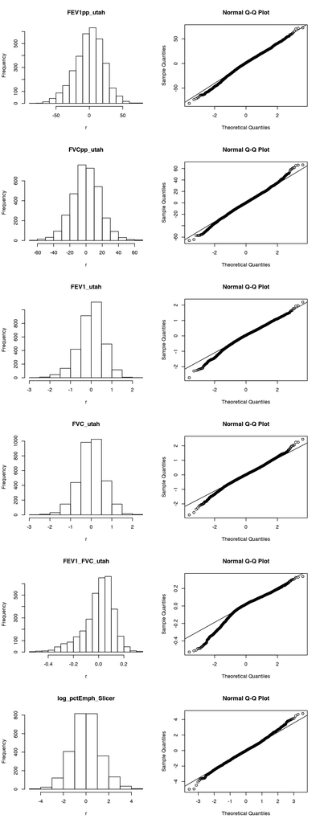

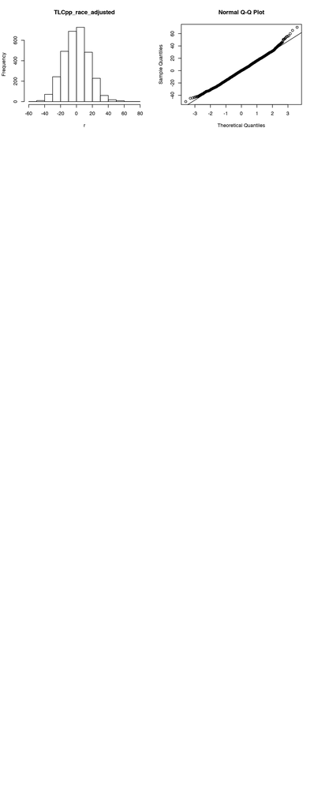